# Compounding (grouping) of LC-MS features

21 November 2021

#### Package

xcms 3.16.1

**Package**: *xcms*  
**Authors**: Johannes Rainer  
**Modified**: 2021-10-26 14:51:41  
**Compiled**: Sun Nov 21 08:13:29 2021

# 1 Introduction

In a typical LC-MS-based metabolomics experiment compounds eluting from the chromatography are first ionized before being measured by mass spectrometry (MS). During the ionization different (multiple) ions can be generated from the same compound which all will be measured by MS. In general, the resulting data is then pre-processed to identify chromatographic peaks in the data and to group these across samples in the correspondence analysis. The result are distinct LC-MS features, characterized by their specific m/z and retention time range. Different ions generated during ionization will be detected as different features. *Compounding* aims now at grouping such features presumably representing signal from the same originating compound to reduce data set complexity (and to aid in subsequent annotation steps). General MS feature grouping functionality if defined by the *MsFeatures* package with additional functionality being implemented in the `xcms` package to enable the compounding of LC-MS data.

This document provides a simple compounding workflow using `xcms`. Note that the present functionality does not (yet) *aggregate* or combine the actual features per values, but does only define the feature groups (one per compound).

# 2 Compounding of LC-MS data

We demonstrate the compounding (feature grouping) functionality on the simple toy data set used also in the *xcms* package and provided through the `faahKO` package. This data set consists of samples from 4 mice with knock-out of the fatty acid amide hydrolase (FAAH) and 4 wild type mice. Pre-processing of this data set is described in detail in the *xcms* vignette of the `xcms` package. Below we load all required packages and the result from this pre-processing updating also the location of the respective raw data files on the current machine.

```r
library(xcms)
library(faahKO)
library(MsFeatures)

data("xdata")
## Update the path to the files for the local system
dirname(xdata) <- c(rep(system.file("cdf", "KO", package = "faahKO"), 4),
                    rep(system.file("cdf", "WT", package = "faahKO"), 4))
```

Before performing the feature grouping we inspect the result object. With `featureDefinitions` we can extract the results from the correspondence analysis.

```r
featureDefinitions(xdata)
```

```
## DataFrame with 225 rows and 11 columns
##           mzmed     mzmin     mzmax     rtmed     rtmin     rtmax    npeaks
##       <numeric> <numeric> <numeric> <numeric> <numeric> <numeric> <numeric>
## FT001     200.1     200.1     200.1   2901.63   2880.73   2922.53         2
## FT002     205.0     205.0     205.0   2789.39   2782.30   2795.36         8
## FT003     206.0     206.0     206.0   2788.73   2780.73   2792.86         7
## FT004     207.1     207.1     207.1   2718.12   2713.21   2726.70         7
## FT005     219.1     219.1     219.1   2518.82   2517.40   2520.81         3
## ...         ...       ...       ...       ...       ...       ...       ...
## FT221    591.30     591.3     591.3   3005.03   2992.87   3006.05         5
## FT222    592.15     592.1     592.3   3022.11   2981.91   3107.59         6
## FT223    594.20     594.2     594.2   3418.16   3359.10   3427.90         3
## FT224    595.25     595.2     595.3   3010.15   2992.87   3013.77         6
## FT225    596.20     596.2     596.2   2997.91   2992.87   3002.95         2
##              KO        WT            peakidx  ms_level
##       <numeric> <numeric>             <list> <integer>
## FT001         2         0  287, 679,1577,...         1
## FT002         4         4     47,272,542,...         1
## FT003         3         4     32,259,663,...         1
## FT004         4         3     19,249,525,...         1
## FT005         1         2  639, 788,1376,...         1
## ...         ...       ...                ...       ...
## FT221         2         3    349,684,880,...         1
## FT222         1         3     86,861,862,...         1
## FT223         1         2  604, 985,1543,...         1
## FT224         2         3     67,353,876,...         1
## FT225         0         2  866,1447,1643,...         1
```

Each row in this data frame represents the definition of one feature, with its average and range of m/z and retention time. Column `"peakidx"` provides the index of each chromatographic peak which is assigned to the feature in the `chromPeaks` matrix of the result object. The `featureValues` function allows to extract *feature values*, i.e. a matrix with feature abundances, one row per feature and columns representing the samples of the present data set.

Below we extract the feature values with and without *filled-in* peak data. Without the gap-filled data only abundances from **detected** chromatographic peaks are reported. In the gap-filled data, for samples in which no chromatographic peak for a feature was detected, all signal from the m/z - retention time range defined based on the detected chromatographic peaks was integrated.

```r
head(featureValues(xdata, filled = FALSE))
```

```
##        ko15.CDF  ko16.CDF  ko21.CDF  ko22.CDF  wt15.CDF  wt16.CDF  wt21.CDF
## FT001        NA  506848.9        NA  169955.6        NA        NA        NA
## FT002 1924712.0 1757151.0 1383416.7 1180288.2 2129885.1 1634342.0 1623589.2
## FT003  213659.3  289500.7        NA  178285.7  253825.6  241844.4  240606.0
## FT004  349011.5  451863.7  343897.8  208002.8  364609.8  360908.9        NA
## FT005        NA        NA        NA  107348.5  223951.8        NA        NA
## FT006  286221.4        NA  164009.0  149097.6  255697.7  311296.8  366441.5
##         wt22.CDF
## FT001         NA
## FT002 1354004.93
## FT003  185399.47
## FT004  221937.53
## FT005   84772.92
## FT006  271128.02
```

```r
head(featureValues(xdata, filled = TRUE))
```

```
##        ko15.CDF   ko16.CDF   ko21.CDF  ko22.CDF  wt15.CDF  wt16.CDF  wt21.CDF
## FT001  159738.1  506848.88  113441.08  169955.6  216096.6  145509.7  230477.9
## FT002 1924712.0 1757150.96 1383416.72 1180288.2 2129885.1 1634342.0 1623589.2
## FT003  213659.3  289500.67  162897.19  178285.7  253825.6  241844.4  240606.0
## FT004  349011.5  451863.66  343897.76  208002.8  364609.8  360908.9  223322.5
## FT005  135978.5   25524.79   71530.84  107348.5  223951.8  134398.9  190203.8
## FT006  286221.4  289908.23  164008.97  149097.6  255697.7  311296.8  366441.5
##         wt22.CDF
## FT001  140551.30
## FT002 1354004.93
## FT003  185399.47
## FT004  221937.53
## FT005   84772.92
## FT006  271128.02
```

In total 225 features have been defined in the present data set, many of which most likely represent signal from different ions (adducts or isotopes) of the same compound. The aim of the grouping functions of are now to define which features most likely come from the same original compound. The feature grouping functions base on the following assumptions/properties of LC-MS data:

- Features (ions) of the same compound should have similar retention time.
- The abundance of features (ions) of the same compound should have a similar pattern across samples, i.e. if a compound is highly concentrated in one sample and low in another, all ions from it should follow the same pattern.
- The peak shape of extracted ion chromatograms (EIC) of features of the same compound should be similar as it should follow the elution pattern of the original compound from the LC.

The main method to perform the feature grouping is called `groupFeatures` which takes an `XCMSnExp` object (result object from the `xcms` pre-processing) as input as well as a parameter object to chose the grouping algorithm and specify its settings. `xcms` provides and supports the following grouping approaches:

- `SimilarRtimeParam`: perform an initial grouping based on similar retention time.
- `AbundanceSimilarityParam`: perform a feature grouping based on correlation of feature abundances (values) across samples.
- `EicSimilarityParam`: perform a feature grouping based on correlation of EICs.

Calling `groupFeatures` on an `xcms` result object will perform a feature grouping assigning each feature in the data set to a *feature group*. These feature groups are stored as an additional column called `"feature_group"` in the `featureDefinition` data frame of the result object and can be accessed with the `featureGroups` function. Any subsequent `groupFeature` call will *sub-group* (refine) the identified feature groups further. It is thus possible to use a single grouping approach, or to combine multiple of them to generate the desired feature grouping. While the individual feature grouping algorithms can be called in any order, it is advisable to use the `EicSimilarityParam` as last refinement step, because it is the computationally most expensive one, especially if applied to a result object without any pre-defined feature groups or if the feature groups are very large. In the subsequent sections we will apply the various feature grouping approaches subsequently.

Note also that we perform here a grouping of all defined features, but it would also be possible to *just* group a subset of interesting features (e.g. features found significant by a statistical analysis of the data set). This is described in the last section of this vignette.

## 2.1 Grouping of features by similar retention time

The most intuitive and simple way to group features is based on their retention time. Before we perform this initial grouping we evaluate retention times and m/z of all features in the present data set.

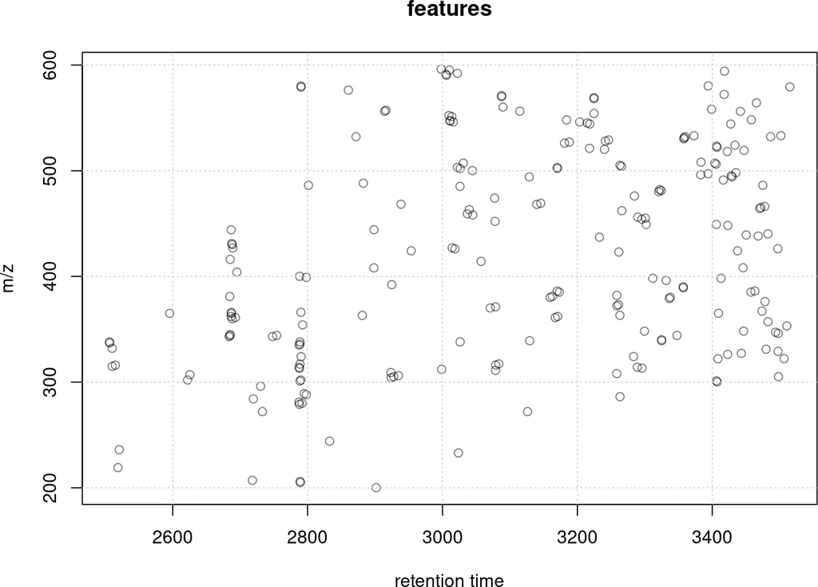

Figure 1: Plot of retention times and m/z for all features in the data set

```r
plot(featureDefinitions(xdata)$rtmed, featureDefinitions(xdata)$mzmed,
     xlab = "retention time", ylab = "m/z", main = "features",
     col = "#00000080")
grid()
```

Several features with about the same retention time (but different m/z) can be seen, especially at the beginning of the LC. We thus below group features within a retention time window of 10 seconds into *feature groups*.

```r
xdata <- groupFeatures(xdata, param = SimilarRtimeParam(10))
```

The results from the feature grouping can be accessed with the `featureGroups` function. Below we determine the size of each of these feature groups (i.e. how many features are grouped together).

```r
table(featureGroups(xdata))
```

```
##
## FG.001 FG.002 FG.003 FG.004 FG.005 FG.006 FG.007 FG.008 FG.009 FG.010 FG.011
##      3      3      3      3      2      4      5      6      4      2      5
## FG.012 FG.013 FG.014 FG.015 FG.016 FG.017 FG.018 FG.019 FG.020 FG.021 FG.022
##      3      4      3      5      3      3      5      3      3      3      3
## FG.023 FG.024 FG.025 FG.026 FG.027 FG.028 FG.029 FG.030 FG.031 FG.032 FG.033
##      3      3      6      3      3      3      3      2      3      3      4
## FG.034 FG.035 FG.036 FG.037 FG.038 FG.039 FG.040 FG.041 FG.042 FG.043 FG.044
##      3      2      2      3      2      2      4      2      2      2      3
## FG.045 FG.046 FG.047 FG.048 FG.049 FG.050 FG.051 FG.052 FG.053 FG.054 FG.055
##      4      2      3      3      3      2      2      3      4      2      3
## FG.056 FG.057 FG.058 FG.059 FG.060 FG.061 FG.062 FG.063 FG.064 FG.065 FG.066
##      2      2      2      3      2      3      2      2      2      3      2
## FG.067 FG.068 FG.069 FG.070 FG.071 FG.072 FG.073 FG.074 FG.075 FG.076 FG.077
##      2      3      2      2      2      3      2      2      1      1      1
## FG.078 FG.079 FG.080 FG.081 FG.082 FG.083 FG.084
##      1      1      1      1      1      1      1
```

In addition we visualize these feature groups with the `plotFeatureGroups` function which shows all features in the m/z - retention time space with grouped features being connected with a line.

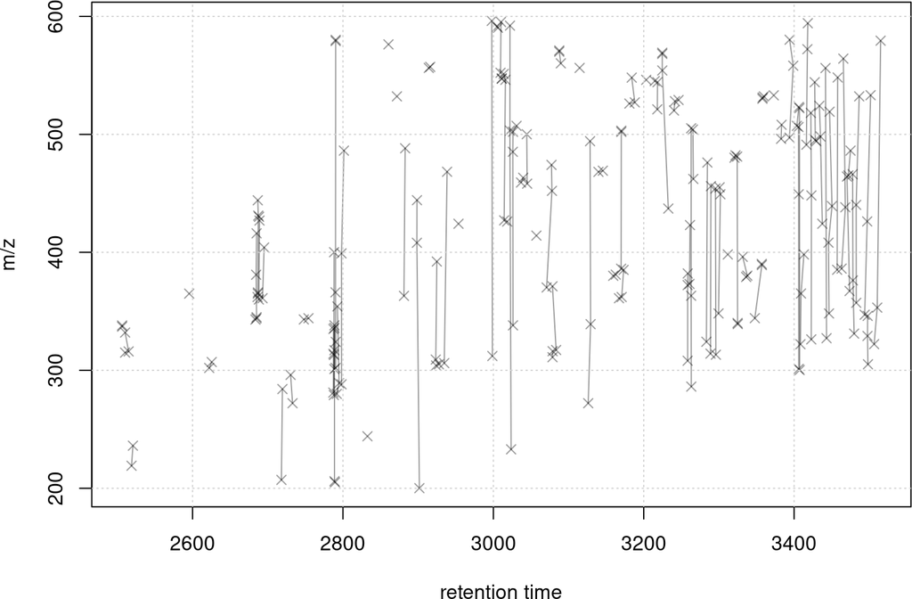

Figure 2: Feature groups defined with a rt window of 10 seconds

```r
plotFeatureGroups(xdata)
grid()
```

Let’s assume we don’t agree with this feature grouping, also knowing that there were quite large shifts in retention times between runs. We thus re-perform the feature grouping based on similar retention time with a larger rt window. Prior to the `groupFeatures` call we have however to drop the previously defined feature groups as otherwise these would be simply *refined* (i.e. further subgrouped).

```r
## Remove previous feature grouping results to repeat the rtime-based
## feature grouping with different setting
featureDefinitions(xdata)$feature_group <- NULL

## Repeat the grouping
xdata <- groupFeatures(xdata, SimilarRtimeParam(20))
table(featureGroups(xdata))
```

```
##
## FG.001 FG.002 FG.003 FG.004 FG.005 FG.006 FG.007 FG.008 FG.009 FG.010 FG.011
##      3      3      3      3      2      4      5      6      4      2      5
## FG.012 FG.013 FG.014 FG.015 FG.016 FG.017 FG.018 FG.019 FG.020 FG.021 FG.022
##      3      4      3      5      3      3      5      3      3      3      3
## FG.023 FG.024 FG.025 FG.026 FG.027 FG.028 FG.029 FG.030 FG.031 FG.032 FG.033
##      3      3      6      3      3      3      4      2      3      3      4
## FG.034 FG.035 FG.036 FG.037 FG.038 FG.039 FG.040 FG.041 FG.042 FG.043 FG.044
##      3      2      3      3      2      2      4      3      2      2      4
## FG.045 FG.046 FG.047 FG.048 FG.049 FG.050 FG.051 FG.052 FG.053 FG.054 FG.055
##      4      2      3      3      3      2      2      3      4      2      3
## FG.056 FG.057 FG.058 FG.059 FG.060 FG.061 FG.062 FG.063 FG.064 FG.065 FG.066
##      3      2      2      3      3      3      2      2      2      3      2
## FG.067 FG.068 FG.069 FG.070 FG.071 FG.072 FG.073 FG.074 FG.075 FG.076 FG.077
##      2      3      2      2      3      3      2      2      1      1      1
```

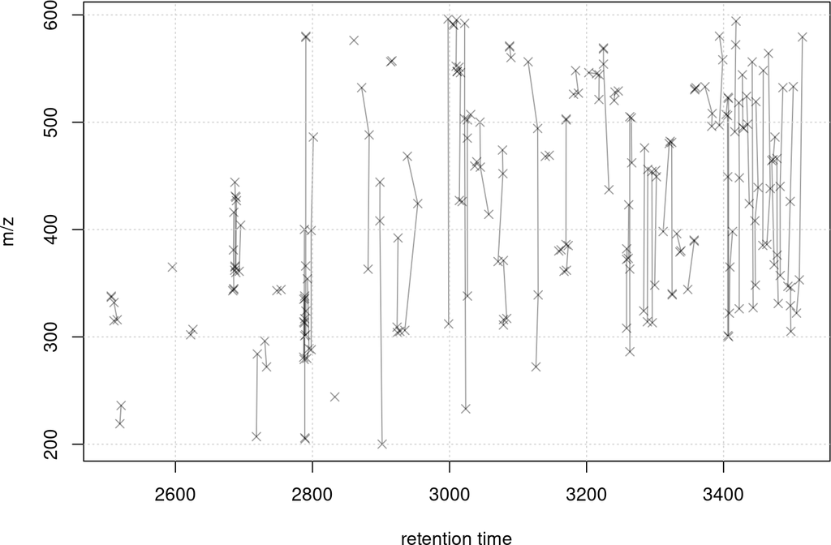

Figure 3: Feature groups defined with a rt window of 20 seconds

```r
plotFeatureGroups(xdata)
grid()
```

Grouping by similar retention time grouped the in total 225 features into 77 feature groups.

## 2.2 Grouping of features by abundance correlation across samples

Assuming we are OK with the *crude* initial feature grouping from the previous section, we can next *refine* the feature groups considering also the feature abundances across samples. We can use the `groupFeatures` method with an `AbundanceSimilarityParam` object. This approach performs a pairwise correlation between the feature values (abundances; across samples) between all features of a predefined feature group (such as defined in the previous section). Features that have a correlation `>= threshold` are grouped together. Feature grouping based on this approach works best for features with a higher variability in their concentration across samples. Parameter `subset` allows to restrict the analysis to a subset of samples and allows thus to e.g. exclude QC sample pools from this correlation as these could artificially increase the correlation. Other parameters are passed directly to the internal `featureValues` call that extracts the feature values on which the correlation should be performed.

Before performing the grouping we could also evaluate the correlation of features based on their (log2 transformed) abundances across samples with a heatmap.

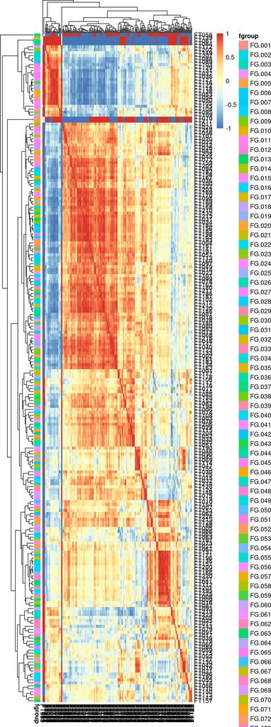

Figure 4: Correlation of features based on feature abundances

```r
library(pheatmap)
fvals <- log2(featureValues(xdata, filled = TRUE))

cormat <- cor(t(fvals), use = "pairwise.complete.obs")
ann <- data.frame(fgroup = featureGroups(xdata))
rownames(ann) <- rownames(cormat)

res <- pheatmap(cormat, annotation_row = ann, cluster_rows = TRUE,
                cluster_cols = TRUE)
```

Some large correlations can be observed for several groups of features, but many of them are not within the same *feature group* that were defined in the previous section (i.e. are not eluting at the same time).

Below we use the `groupFeatures` with the `AbundanceSimilarityParam` to group features with a correlation higher than 0.7 including both detected and filled-in signal. Whether filled-in or only detected signal should be used in the correlation analysis should be evaluated from data set to data set. By specifying `transform = log2` we tell the function to log2 transform the abundance prior to the correlation analysis. See the help page for `groupFeatures` with `AbundanceSimilarityParam` in the `xcms` package for details and options.

```r
xdata <- groupFeatures(xdata, AbundanceSimilarityParam(threshold = 0.7,
                                                       transform = log2),
                       filled = TRUE)
table(featureGroups(xdata))
```

```
##
## FG.001.001 FG.001.002 FG.002.001 FG.002.002 FG.002.003 FG.003.001 FG.003.002
##          2          1          1          1          1          2          1
## FG.004.001 FG.005.001 FG.006.001 FG.006.002 FG.007.001 FG.007.002 FG.007.003
##          3          2          3          1          2          1          1
## FG.007.004 FG.008.001 FG.008.002 FG.008.003 FG.008.004 FG.009.001 FG.009.002
##          1          3          1          1          1          3          1
## FG.010.001 FG.011.001 FG.011.002 FG.011.003 FG.012.001 FG.013.001 FG.013.002
##          2          2          2          1          3          2          1
## FG.013.003 FG.014.001 FG.014.002 FG.015.001 FG.015.002 FG.015.003 FG.015.004
##          1          2          1          2          1          1          1
## FG.016.001 FG.016.002 FG.017.001 FG.017.002 FG.018.001 FG.018.002 FG.018.003
##          2          1          2          1          2          1          1
## FG.018.004 FG.019.001 FG.019.002 FG.019.003 FG.020.001 FG.020.002 FG.021.001
##          1          1          1          1          2          1          1
## FG.021.002 FG.021.003 FG.022.001 FG.022.002 FG.022.003 FG.023.001 FG.023.002
##          1          1          1          1          1          2          1
## FG.024.001 FG.024.002 FG.024.003 FG.025.001 FG.025.002 FG.025.003 FG.025.004
##          1          1          1          2          1          1          1
## FG.025.005 FG.026.001 FG.026.002 FG.026.003 FG.027.001 FG.027.002 FG.027.003
##          1          1          1          1          1          1          1
## FG.028.001 FG.028.002 FG.029.001 FG.029.002 FG.030.001 FG.030.002 FG.031.001
##          2          1          2          2          1          1          3
## FG.032.001 FG.032.002 FG.032.003 FG.033.001 FG.033.002 FG.033.003 FG.033.004
##          1          1          1          1          1          1          1
## FG.034.001 FG.034.002 FG.034.003 FG.035.001 FG.035.002 FG.036.001 FG.036.002
##          1          1          1          1          1          2          1
## FG.037.001 FG.037.002 FG.038.001 FG.039.001 FG.040.001 FG.040.002 FG.041.001
##          2          1          2          2          2          2          1
## FG.041.002 FG.041.003 FG.042.001 FG.042.002 FG.043.001 FG.044.001 FG.044.002
##          1          1          1          1          2          2          1
## FG.044.003 FG.045.001 FG.045.002 FG.045.003 FG.045.004 FG.046.001 FG.047.001
##          1          1          1          1          1          2          1
## FG.047.002 FG.047.003 FG.048.001 FG.048.002 FG.048.003 FG.049.001 FG.049.002
##          1          1          1          1          1          2          1
## FG.050.001 FG.050.002 FG.051.001 FG.052.001 FG.052.002 FG.053.001 FG.053.002
##          1          1          2          2          1          2          1
## FG.053.003 FG.054.001 FG.054.002 FG.055.001 FG.055.002 FG.055.003 FG.056.001
##          1          1          1          1          1          1          1
## FG.056.002 FG.056.003 FG.057.001 FG.058.001 FG.058.002 FG.059.001 FG.059.002
##          1          1          2          1          1          1          1
## FG.059.003 FG.060.001 FG.060.002 FG.061.001 FG.061.002 FG.062.001 FG.062.002
##          1          2          1          2          1          1          1
## FG.063.001 FG.064.001 FG.064.002 FG.065.001 FG.065.002 FG.066.001 FG.066.002
##          2          1          1          2          1          1          1
## FG.067.001 FG.067.002 FG.068.001 FG.069.001 FG.070.001 FG.070.002 FG.071.001
##          1          1          3          2          1          1          2
## FG.071.002 FG.072.001 FG.072.002 FG.073.001 FG.073.002 FG.074.001 FG.075.001
##          1          2          1          1          1          2          1
## FG.076.001 FG.077.001
##          1          1
```

Many of the larger retention time-based feature groups have been splitted into two or more sub-groups based on the correlation of their feature abundances. We evaluate this for one specific feature group `"FG.040"` by plotting their pairwise correlation.

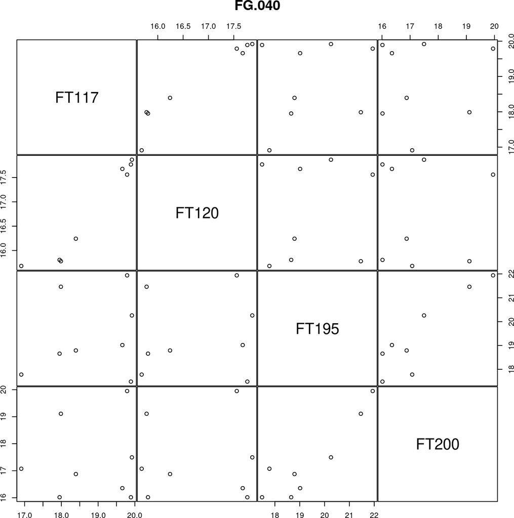

Figure 5: Pairwise correlation plot for all features initially grouped into the feature group FG.040

```r
fts <- grep("FG.040", featureGroups(xdata))
pairs(t(fvals[fts, ]), gap = 0.1, main = "FG.040")
```

Indeed, correlations can be seen only between some of the features in this retention time feature group, e.g. between *FT117* and *FT120* and between *FT195* and *FT200*. Note however that this abundance correlation suffers from relatively few samples (8 in total), and a relatively small variance in abundances across these samples.

After feature grouping by abundance correlation, the 225 features have been grouped into 170 feature groups.

## 2.3 Grouping of features by similarity of their EICs

The chromatographic peak shape of an ion of a compound should be highly similar to the elution pattern of this compound. Thus, features from the same compound are assumed to have similar peak shapes of their EICs **within the same sample**. A grouping of features based on similarity of their EICs can be performed with the `groupFeatures` and the `EicSimilarityParam` object. It is advisable to perform the peak shape correlation only on a subset of samples (because peak shape correlation is computationally intense and because chromatographic peaks of low intensity features are notoriously noisy). The `EicSimilarityParam` approach has thus the parameter `n` which allows to select the number of top samples (ordered by total intensity of feature abundances per feature group) on which the correlation should be performed. With an value of `n = 3`, the 3 samples with the highest signal for all features in that group will be first identified for each feature group and then a pairwise similarity calculation will be performed within each of these samples. The resulting similarity score from these 3 samples will then be aggregated into a single score by taking the 75% quantile across the 3 samples. This value is then subsequently compared with the cut-off for similarity (parameter `threshold`) and features with a score `>= threshold` are grouped into the same feature group.

Below we group the features based on similarity of their EICs in the two samples with the highest total signal for the respective feature groups. By default, a Pearson correlation coefficient is used as similarity score but any similarity/distance metric function could be used instead (parameter `FUN` of the `EicSimilarityParam` - see the respective help page `?EicSimilarityParam` for details and options). We define as a threshold a correlation coefficient of 0.7.

```r
xdata <- groupFeatures(xdata, EicSimilarityParam(threshold = 0.7, n = 2))
```

This is the most computationally intense approach since it involves also loading the raw MS data to extract the ion chromatograms for each feature. The results of the grouping are shown below.

```r
table(featureGroups(xdata))
```

```
##
## FG.001.001.001 FG.001.002.001 FG.002.001.001 FG.002.002.001 FG.002.003.001
##              2              1              1              1              1
## FG.003.001.001 FG.003.002.001 FG.004.001.001 FG.005.001.001 FG.006.001.001
##              2              1              3              2              3
## FG.006.002.001 FG.007.001.001 FG.007.002.001 FG.007.003.001 FG.007.004.001
##              1              2              1              1              1
## FG.008.001.001 FG.008.001.002 FG.008.002.001 FG.008.003.001 FG.008.004.001
##              2              1              1              1              1
## FG.009.001.001 FG.009.002.001 FG.010.001.001 FG.010.001.002 FG.011.001.001
##              3              1              1              1              2
## FG.011.002.001 FG.011.003.001 FG.012.001.001 FG.013.001.001 FG.013.002.001
##              2              1              3              2              1
## FG.013.003.001 FG.014.001.001 FG.014.002.001 FG.015.001.001 FG.015.002.001
##              1              2              1              2              1
## FG.015.003.001 FG.015.004.001 FG.016.001.001 FG.016.002.001 FG.017.001.001
##              1              1              2              1              2
## FG.017.002.001 FG.018.001.001 FG.018.002.001 FG.018.003.001 FG.018.004.001
##              1              2              1              1              1
## FG.019.001.001 FG.019.002.001 FG.019.003.001 FG.020.001.001 FG.020.001.002
##              1              1              1              1              1
## FG.020.002.001 FG.021.001.001 FG.021.002.001 FG.021.003.001 FG.022.001.001
##              1              1              1              1              1
## FG.022.002.001 FG.022.003.001 FG.023.001.001 FG.023.002.001 FG.024.001.001
##              1              1              2              1              1
## FG.024.002.001 FG.024.003.001 FG.025.001.001 FG.025.001.002 FG.025.002.001
##              1              1              1              1              1
## FG.025.003.001 FG.025.004.001 FG.025.005.001 FG.026.001.001 FG.026.002.001
##              1              1              1              1              1
## FG.026.003.001 FG.027.001.001 FG.027.002.001 FG.027.003.001 FG.028.001.001
##              1              1              1              1              2
## FG.028.002.001 FG.029.001.001 FG.029.002.001 FG.029.002.002 FG.030.001.001
##              1              2              1              1              1
## FG.030.002.001 FG.031.001.001 FG.032.001.001 FG.032.002.001 FG.032.003.001
##              1              3              1              1              1
## FG.033.001.001 FG.033.002.001 FG.033.003.001 FG.033.004.001 FG.034.001.001
##              1              1              1              1              1
## FG.034.002.001 FG.034.003.001 FG.035.001.001 FG.035.002.001 FG.036.001.001
##              1              1              1              1              1
## FG.036.001.002 FG.036.002.001 FG.037.001.001 FG.037.002.001 FG.038.001.001
```

[output cut: 20 more lines]

```
##              1              1              1              1              1
## FG.060.001.001 FG.060.001.002 FG.060.002.001 FG.061.001.001 FG.061.002.001
##              1              1              1              2              1
## FG.062.001.001 FG.062.002.001 FG.063.001.001 FG.064.001.001 FG.064.002.001
##              1              1              2              1              1
## FG.065.001.001 FG.065.002.001 FG.066.001.001 FG.066.002.001 FG.067.001.001
##              2              1              1              1              1
## FG.067.002.001 FG.068.001.001 FG.068.001.002 FG.069.001.001 FG.070.001.001
##              1              2              1              2              1
## FG.070.002.001 FG.071.001.001 FG.071.001.002 FG.071.002.001 FG.072.001.001
##              1              1              1              1              1
## FG.072.001.002 FG.072.002.001 FG.073.001.001 FG.073.002.001 FG.074.001.001
##              1              1              1              1              2
## FG.075.001.001 FG.076.001.001 FG.077.001.001
##              1              1              1
```

In most cases, pre-defined feature groups (by the abundance correlation) were not further subdivided. Below we evaluate some of the feature groups, starting with *FG.008.001* which was split into two different feature groups based on EIC correlation. We first extract the EICs for all features from this initial feature group. With `n = 1` we specify to extract the EIC only from the sample with the highest intensity.

```r
fts <- grep("FG.008.001", featureGroups(xdata))
eics <- featureChromatograms(xdata, features = fts,
                             filled = TRUE, n = 1)
```

Next we plot the EICs using a different color for each of the subgroups. With `peakType = "none"` we disable the highlighting of the detected chromatographic peaks.

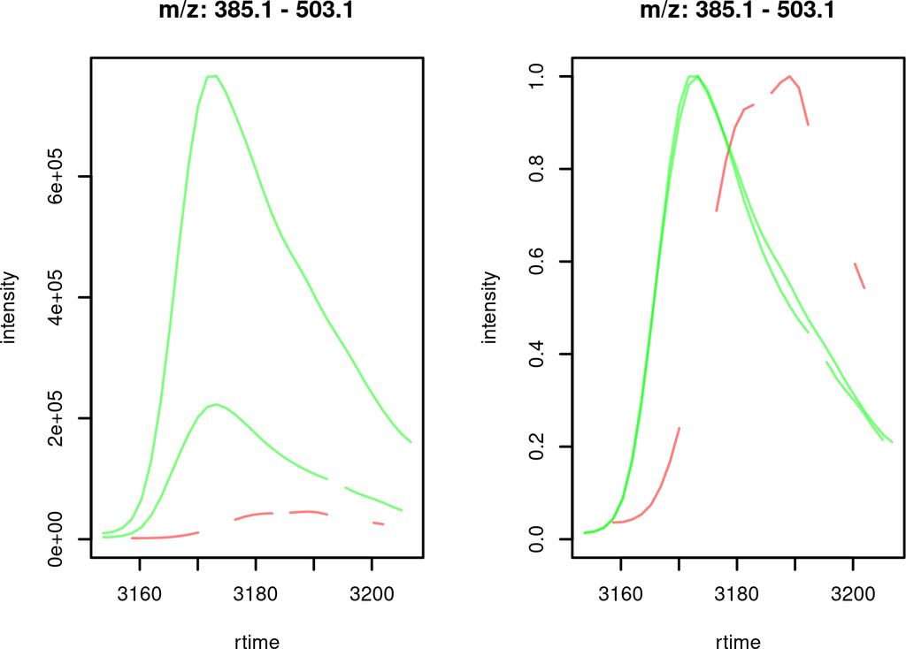

Figure 6: EICs of features from feature group FG.008.001 in the same sample  
Shown are the actual intensities (left) and intensities normalized to 1 (right). Features being part of the same feature group after grouping by EIC similarity are shown in the same color.

```r
cols <- c("#ff000080", "#00ff0080")
names(cols) <- unique(featureGroups(xdata)[fts])

par(mfrow = c(1, 2))
plotChromatogramsOverlay(eics, col = cols[featureGroups(xdata)[fts]],
                         lwd = 2, peakType = "none")
plotChromatogramsOverlay(normalize(eics),
                         col = cols[featureGroups(xdata)[fts]],
                         lwd = 2, peakType = "none")
```

One of the features within the original feature group was separated from the other two because of a low similarity of their EICs. In fact, the feature’s EIC is shifted in retention time dimension and can thus not represent the signal from the same compound.

We evaluate next the sub-grouping in another feature group.

```r
fts <- grep("FG.068.001", featureGroups(xdata))
eics <- featureChromatograms(xdata, features = fts,
                             filled = TRUE, n = 1)
```

Next we plot the EICs using a different color for each of the subgroups.

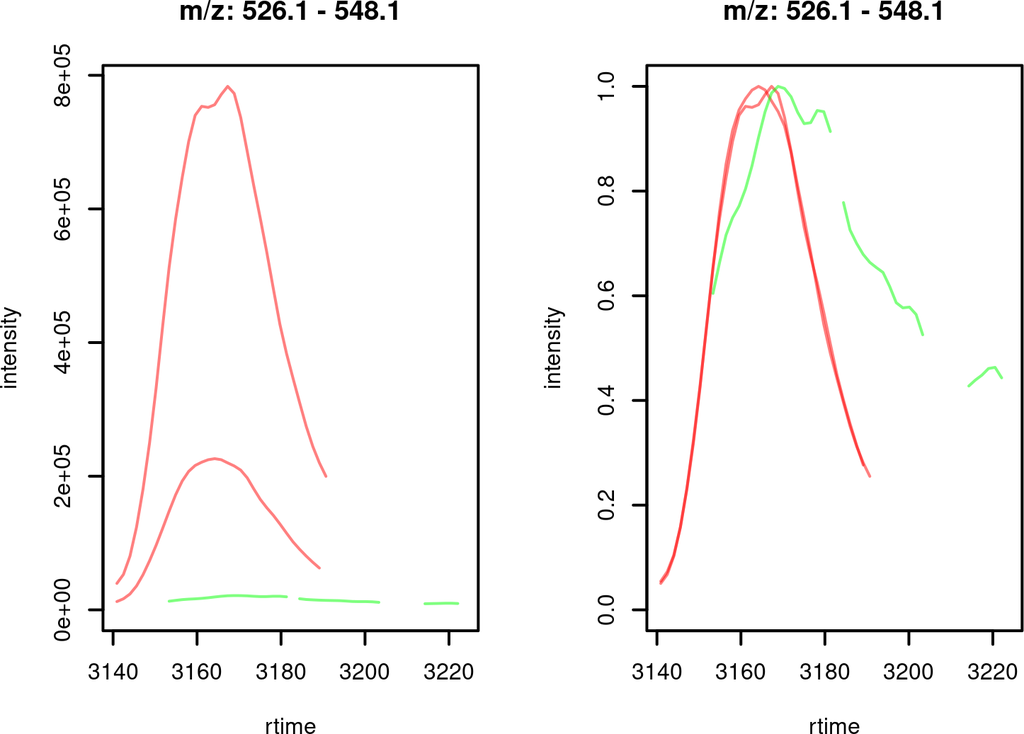

Figure 7: EICs for features from feature group FG.068.001 in the same sample  
Shown are the actual intensities (left) and intensities normalized to 1 (right). Features being part of the same feature group after grouping by EIC similarity are shown in the same color.

```r
cols <- c("#ff000080", "#00ff0080")
names(cols) <- unique(featureGroups(xdata)[fts])

par(mfrow = c(1, 2))
plotChromatogramsOverlay(eics, col = cols[featureGroups(xdata)[fts]],
                         lwd = 2, peakType = "none")
plotChromatogramsOverlay(normalize(eics),
                         col = cols[featureGroups(xdata)[fts]],
                         lwd = 2, peakType = "none")
```

Based on the EIC correlation, the initial feature group *FG.068.001* was grouped into two separate sub-groups.

The grouping based on EIC correlation on the pre-defined feature groups from the previous sections grouped the 225 features into 183 feature groups.

## 2.4 Grouping of subsets of features

In the previous sections we were always considering all features from the data set, but sometimes it could be desirable to just group a pre-defined set of features, for example features found to be of particular interest in a certain experiment (e.g. significant features). This can be easily achieved by assigning the features of interest to a initial feature group, using `NA` as group ID for all other features.

To illustrate this we *reset* all feature groups by setting them to `NA` and assign our features of interest (in this example just 30 randomly selected features) to an initial feature group `"FG"`.

```r
featureDefinitions(xdata)$feature_group <- NA_character_

set.seed(123)
fts_idx <- sample(1:nrow(featureDefinitions(xdata)), 30)
featureDefinitions(xdata)$feature_group[fts_idx] <- "FG"
```

Any call to `groupFeatures` would now simply sub-group this set of 30 features. Any feature which has an `NA` in the `"feature_group"` column will be ignored.

```r
xdata <- groupFeatures(xdata, SimilarRtimeParam(diffRt = 20))
xdata <- groupFeatures(xdata, AbundanceSimilarityParam(threshold = 0.7))
table(featureGroups(xdata))
```

```
##
## FG.001.001 FG.001.002 FG.002.001 FG.003.001 FG.003.002 FG.004.001 FG.004.002
##          2          2          4          2          1          1          1
## FG.004.003 FG.005.001 FG.005.002 FG.006.001 FG.006.002 FG.007.001 FG.008.001
##          1          1          1          1          1          2          1
## FG.009.001 FG.010.001 FG.011.001 FG.012.001 FG.013.001 FG.014.001 FG.015.001
##          1          1          1          1          1          1          1
## FG.016.001 FG.017.001
##          1          1
```

# 4 References